# Read Distribution and Taxonomy Analysis

# Read length distribution of the PacBio HiFi reads

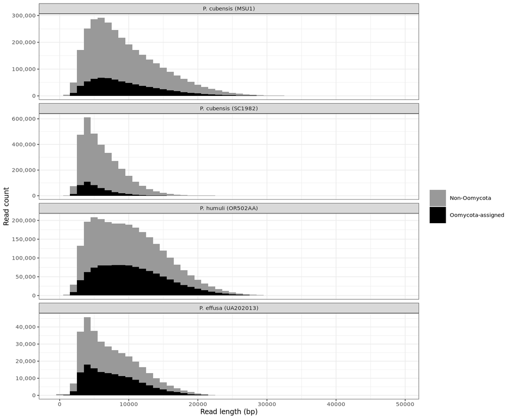

# Taxonomic composition and read GC/coverage

The composition panel uses Kraken2 (PlusPFP) phylum-level assignments; phyla below 5% of a library’s reads are collapsed to “Other”. The GC/coverage panel plots per-read GC content (seqkit `fx2tab`) against per-read median 21-mer self-coverage (KAT `sect`) for the adapter-filtered HiFi reads, coloured by the same phylum categories. Coverage is a proxy for how often a molecule was sampled, not a per-base assembly coverage. Category summaries are written to `data/blobplot-category-summary-by-isolate.tsv`.

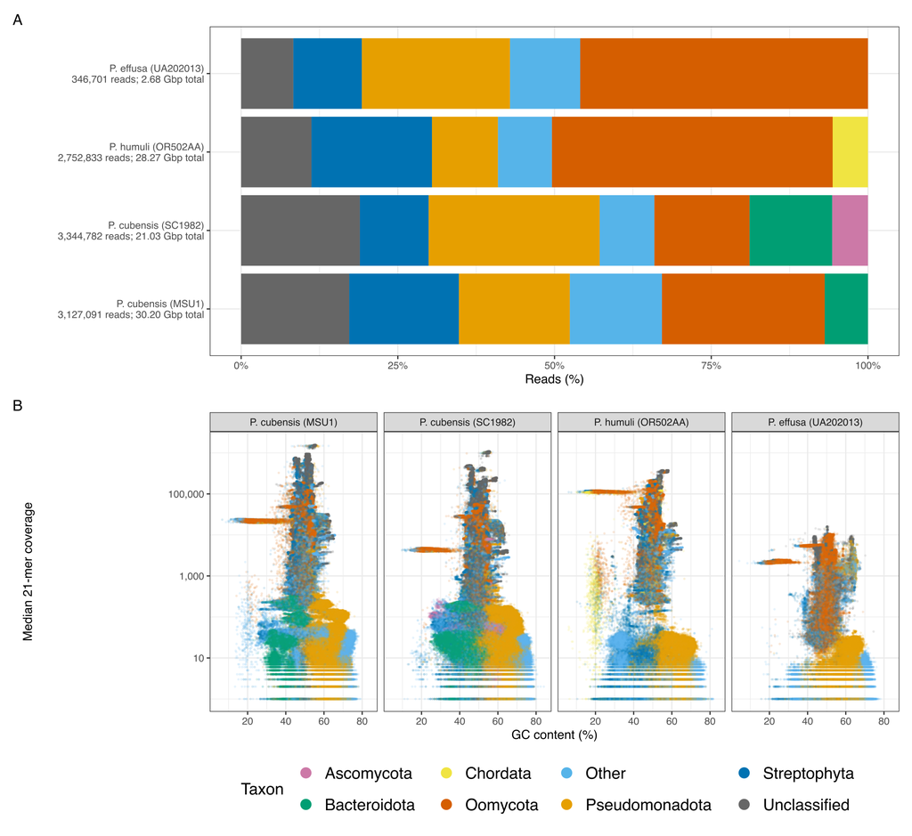

| Isolate | Category | Reads | Mean GC (%) | Mean median coverage |
| --- | --- | --- | --- | --- |
| P. cubensis (MSU1) | Oomycota | 734,886 | 45.4 | 32,807.4 |
| P. cubensis (MSU1) | Other | 713,163 | 51.1 | 6,894.4 |
| P. cubensis (MSU1) | Pseudomonadota | 500,874 | 58.5 | 2,309.5 |
| P. cubensis (MSU1) | Streptophyta | 494,973 | 48.9 | 22,326.5 |
| P. cubensis (MSU1) | unclassified | 487,928 | 49.3 | 169,356.1 |
| P. cubensis (MSU1) | Bacteroidota | 195,267 | 44.9 | 2,090.8 |
| P. cubensis (SC1982) | Pseudomonadota | 852,050 | 60.7 | 611.3 |
| P. cubensis (SC1982) | unclassified | 591,398 | 49.4 | 84,221.7 |
| P. cubensis (SC1982) | Other | 494,799 | 53.0 | 4,350.1 |
| P. cubensis (SC1982) | Oomycota | 474,124 | 47.8 | 20,849.8 |
| P. cubensis (SC1982) | Bacteroidota | 411,591 | 44.2 | 245.2 |
| P. cubensis (SC1982) | Streptophyta | 342,435 | 48.8 | 13,804.9 |
| P. cubensis (SC1982) | Ascomycota | 178,385 | 57.6 | 692.1 |
| P. humuli (OR502AA) | Oomycota | 1,108,409 | 37.6 | 74,596.1 |
| P. humuli (OR502AA) | Other | 490,954 | 48.5 | 5,455.0 |
| P. humuli (OR502AA) | Streptophyta | 475,780 | 47.6 | 15,173.0 |
| P. humuli (OR502AA) | unclassified | 277,656 | 49.0 | 35,336.8 |
| P. humuli (OR502AA) | Pseudomonadota | 260,456 | 55.4 | 4,390.2 |
| P. humuli (OR502AA) | Chordata | 139,578 | 44.5 | 25,158.1 |
| P. effusa (UA202013) | Oomycota | 148,140 | 46.4 | 1,453.6 |
| P. effusa (UA202013) | Pseudomonadota | 76,289 | 59.2 | 86.9 |
| P. effusa (UA202013) | Other | 60,167 | 50.5 | 252.8 |
| P. effusa (UA202013) | Streptophyta | 35,249 | 47.4 | 476.1 |
| P. effusa (UA202013) | unclassified | 26,856 | 48.2 | 887.6 |

## Finding

The full-read profiles reveal taxon-associated GC and coverage patterns. `Pseudomonadota` is concentrated at relatively high GC content and low 21-mer coverage, while `Bacteroidota` tends toward lower GC content and low coverage. `Oomycota` often has higher coverage than these bacterial groups but overlaps substantially with `Streptophyta` and unclassified reads. GC content and coverage can therefore help identify some non-target populations, but a simple threshold on these axes would not cleanly isolate Oomycota-assigned reads. Reads unclassified by Kraken2 should not be assumed to be contaminants.